# castillo_anthony_proj_131

Anthony Castillo

12/5/2019

1. Voter data can be hard to predict because data gathered for measuring how voters view candidates and ballot measures is usually deeply inaccurate. Between faulty polling methodologies (ie - pollsters contacting voters using only landlines, and thus contacting only older voters), terrible wording of questions, and polling agencies with a political agendy in mind, it’s a wonder that people take polls seriously. In addition, people may lie to a pollster to evade facing judgement, or may even experience a change of heart in political opinion altogether from between the polling and actual voting times. Thus, it becomes really difficult to predict voter data.
2. Part of what went right for Nate Silver in 2012 was actually the Republican Party and the US economy going through some structural changes at the time. Namely, the GOP was in the middle of the Tea Party movement, and thus was moving to the right on many issues. Inconveniently for the Tea Party, Romney, one of the last few moderates in the GOP (he was actually pro-choice in his Senate run back in the 90s) got the nomination after Speaker Gingrich, Senator Santorum, and Congressman Paul all were defeated in the 2012 GOP primary. The GOP base (the Tea Party) was disgruntled by this even though the economy had not recovered from the ’08 recession. President Obama had 4 years to produce change and benefits for the American people who were effected by the recession and failed in the eyes of many, and thus many within the media establishment weren’t sure on Obama winning re-eleciton. Thus, Romney blew millions of dollars surrounding himself with focus groups and media consultants who reassured him the presidency was his, and there wasn’t much he had to do about it. Little did Romney know that national polling means little in a presidential election, and that because of the structure of the Electoral College, state polling is largely what counts.

By relating voter opinion to time on a state-by-state basis, Nate Silver was able to predict every single state in the 2012 election. Mixing Bayes’ Theorem, hierarchical modelling, and graph theory, Nate Silver was able to successfully predict the 2012 election with ease. It largely revolved around centering his predictions on how Ohio was going to vote. In political terms, the Democrats hadn’t yet lost the support of the white working class that voted Trump in 2016, and this demographic can be seen primarily in the Rust Belt. Romney, being a white-collar financier, wouldn’t have the appeal unionists in the then-relevant Obama coalition had to those voters. Thus, by Obama winning Ohio, he likely would have also made the appeal to win the swing states necessary for 270 votes in the electoral college.

3. Actually, nothing went wrong in 2016. The Obama coalition no longer exists, the white working class in the Rust Belt felt cheated by the neoliberal globalism pushed by 2nd-term Obama, and then-candidate Trump simply capitalized on Obama’s failures as president and Secretary Clinton’s failures as America’s top diplomat. Simply put, Trump saw an opportunity to push his more paleoconservative/nationalist platform through appealing to the American heartland while maintaining appeal to the religious right, the remnants of the Tea Party, and any Senator Sanders supporters who were disillusioned by the 2016 Democratic primary. I would go as far as say that Trump may have even won in 2012 had he run then, and my evidence is the fact that Obama won 2012 by only 64 electoral votes scattered across four swing states: Florida, Ohio, Virginia, and New Hampshire. I researched the actual voting margins and found Romney only needed 429,464 votes across these four states to win the 270 electoral votes for the presidency. Trump added 2 million votes to the GOP column with Florida and the Rust Belt making up the Electoral College difference. Moreover, I am one of the few people you will ever meet that called the 2016 election well before it happened.

Polling can be made better by divorcing itself from all biases and policy agendas and instead diversifying outreach to voters. This means issuing polls by email or cell phone call. I do not think this will happen, and thus the actual predictions themselves can be made better if we focus more on state-wide sentiments as it pertains to major policy issues. I do see the Sun Belt coming into play in the near future, and I think we can experiment there by testing analytics methods for unstructured data likely voters may yield while on the Internet (ie - scraping keystroke and page visit time data from whatever API is relevant).

| county | fips | candidate | state | votes |
| --- | --- | --- | --- | --- |
| Los Angeles County | 6037 | Hillary Clinton | CA | 2464364 |
| Los Angeles County | 6037 | Donald Trump | CA | 769743 |
| Los Angeles County | 6037 | Gary Johnson | CA | 88968 |
| Los Angeles County | 6037 | Jill Stein | CA | 76465 |
| Los Angeles County | 6037 | Gloria La Riva | CA | 21993 |

```
## [1] 18345     5
```

5. This is just us filtering our data
6. Here, we have total population vote count for all candidates.

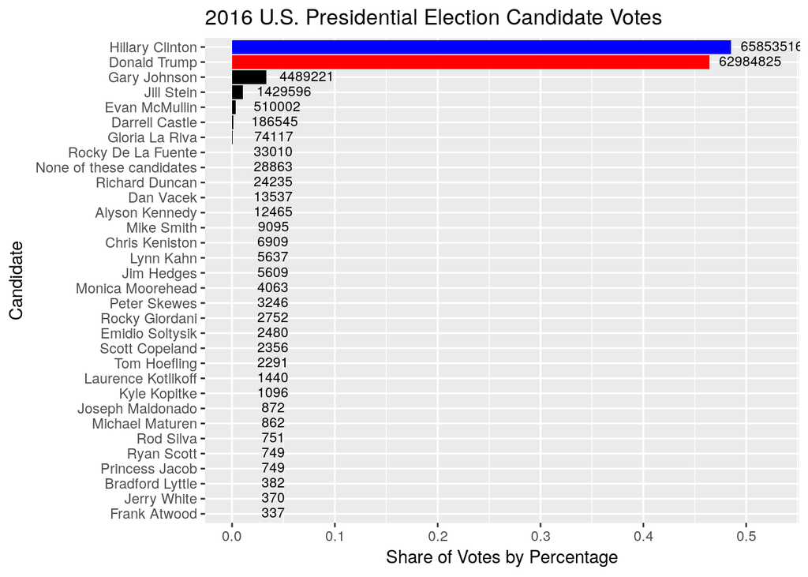

7. Here, we create our county_winner and state_winner objects (no output).

This is our state map.

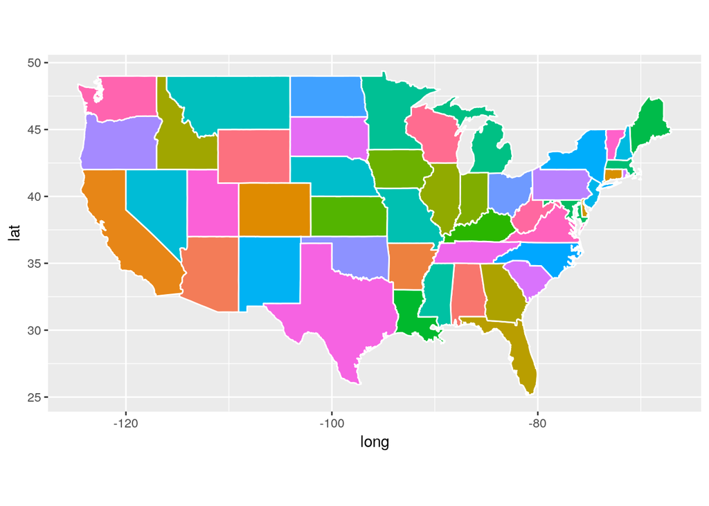

8. This is our county map.

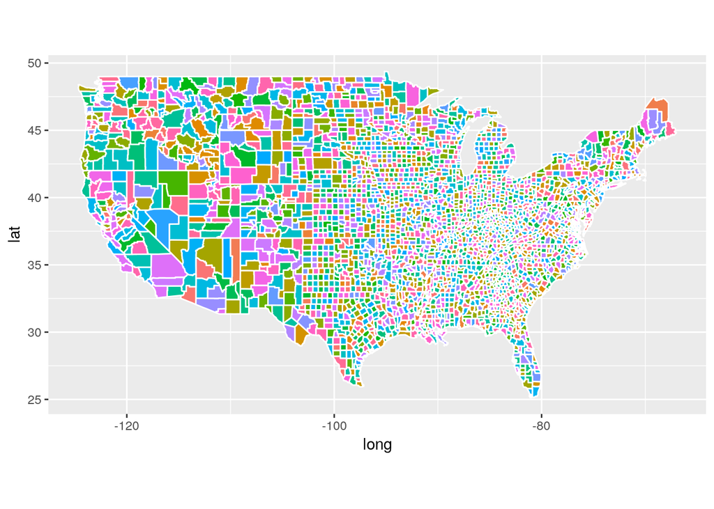

9. This is the state map in accordance with the candidate that won each state in the 2016 presidential election.

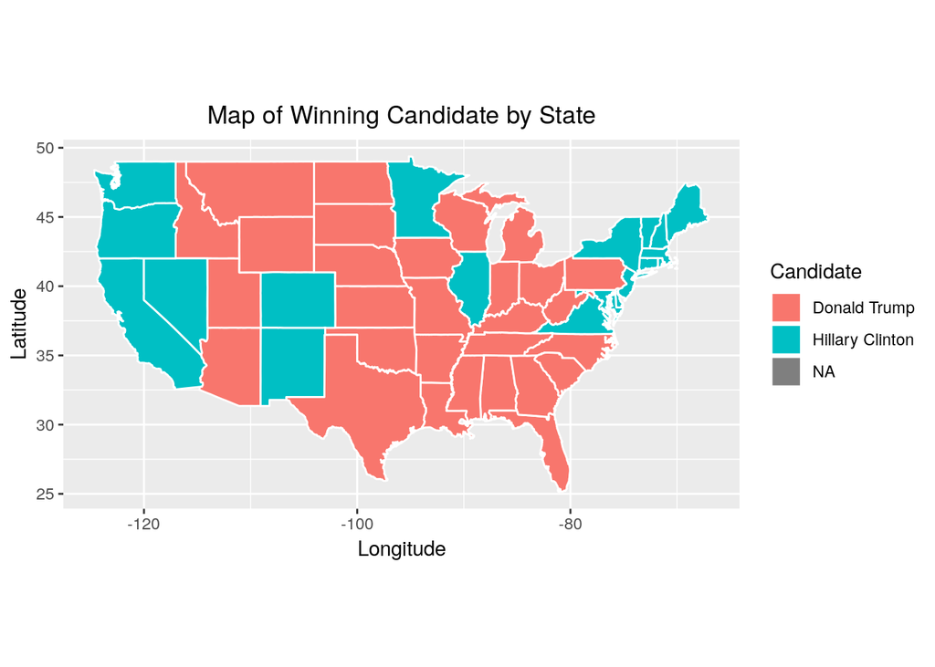

10. Here, we create our fips field for county. I then threw in a plot showing county- by-county results for the election on a visual basis.

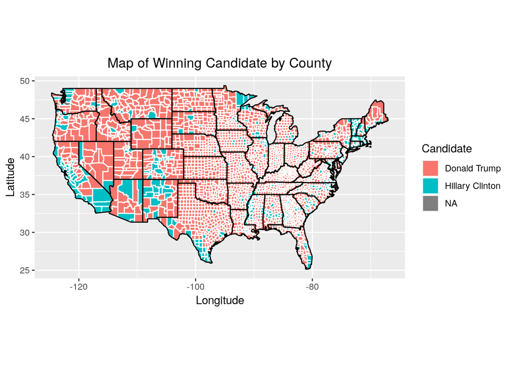

11. This visual is actually really simple. All it shows is average income by state.

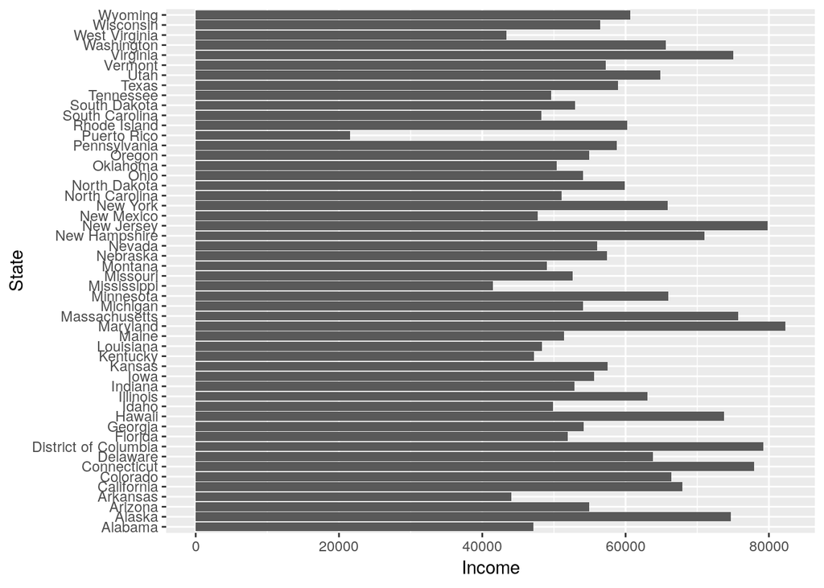

12. Here we cleaned our data and created census.del, census.subct, and census.ct.

```
## # A tibble: 6 x 27
##   State County TotalPop   Men Citizen Minority Income IncomeErr
##   <chr> <chr>     <int> <dbl>   <dbl>    <dbl>  <int>     <int>
## 1 Alab… Autau…     1948  48.3    77.2      9.5  61838     11900
## 2 Alab… Autau…     2156  49.1    77.1     56.4  32303     13538
## 3 Alab… Autau…     2968  46.0    78.7     20.8  44922      5629
## 4 Alab… Autau…     4423  49.1    74.7     15.8  54329      7003
## 5 Alab… Autau…    10763  45.7    71.2     29.3  51965      6935
## 6 Alab… Autau…     3851  46.4    68.6     25    63092      9585
## # ... with 19 more variables: IncomePerCap <int>, IncomePerCapErr <int>,
## #   Poverty <dbl>, ChildPoverty <dbl>, Professional <dbl>, Service <dbl>,
## #   Office <dbl>, Production <dbl>, Drive <dbl>, Carpool <dbl>,
## #   Transit <dbl>, OtherTransp <dbl>, WorkAtHome <dbl>, MeanCommute <dbl>,
## #   Employed <dbl>, PrivateWork <dbl>, SelfEmployed <dbl>,
## #   FamilyWork <dbl>, Unemployment <dbl>
```

```
## # A tibble: 6 x 29
## # Groups:   State, County [1]
##   State County TotalPop   Men Citizen Minority Income IncomeErr
##   <chr> <chr>     <int> <dbl>   <dbl>    <dbl>  <int>     <int>
## 1 Alab… Autau…     1948  48.3    77.2      9.5  61838     11900
## 2 Alab… Autau…     2156  49.1    77.1     56.4  32303     13538
## 3 Alab… Autau…     2968  46.0    78.7     20.8  44922      5629
## 4 Alab… Autau…     4423  49.1    74.7     15.8  54329      7003
## 5 Alab… Autau…    10763  45.7    71.2     29.3  51965      6935
## 6 Alab… Autau…     3851  46.4    68.6     25    63092      9585
## # ... with 21 more variables: IncomePerCap <int>, IncomePerCapErr <int>,
## #   Poverty <dbl>, ChildPoverty <dbl>, Professional <dbl>, Service <dbl>,
## #   Office <dbl>, Production <dbl>, Drive <dbl>, Carpool <dbl>,
## #   Transit <dbl>, OtherTransp <dbl>, WorkAtHome <dbl>, MeanCommute <dbl>,
## #   Employed <dbl>, PrivateWork <dbl>, SelfEmployed <dbl>,
## #   FamilyWork <dbl>, Unemployment <dbl>, CountyTotal <int>,
## #   CountyWeight <dbl>
```

```
## # A tibble: 6 x 27
##   State County TotalPop   Men Citizen Minority Income IncomeErr
##   <chr> <chr>     <int> <dbl>   <dbl>    <dbl>  <dbl>     <dbl>
## 1 Alab… Autau…    55221  580.    73.7     22.5 51696.     7771.
## 2 Alab… Baldw…   195121 1514.    75.7     15.2 51074.     8745.
## 3 Alab… Barbo…    26932  470.    76.9     51.9 32959.     6031.
## 4 Alab… Bibb      22604  213.    77.4     24.2 38887.     5662.
## 5 Alab… Blount    57710  446.    73.4     10.6 46238.     8696.
## 6 Alab… Bullo…    10678  155.    75.5     76.5 33293.     9000.
## # ... with 19 more variables: IncomePerCap <dbl>, IncomePerCapErr <dbl>,
## #   Poverty <dbl>, ChildPoverty <dbl>, Professional <dbl>, Service <dbl>,
## #   Office <dbl>, Production <dbl>, Drive <dbl>, Carpool <dbl>,
## #   Transit <dbl>, OtherTransp <dbl>, WorkAtHome <dbl>, MeanCommute <dbl>,
## #   Employed <dbl>, PrivateWork <dbl>, SelfEmployed <dbl>,
## #   FamilyWork <dbl>, Unemployment <dbl>
```

```
##                          PC1           PC2
## TotalPop         0.102783126  0.3281630451
## Men              0.098972397  0.3247545441
## Citizen         -0.031702114 -0.1822660817
## Minority        -0.178285523  0.2105118335
## Income           0.342764811  0.1444900115
## IncomeErr        0.203165173  0.2425637213
## IncomePerCap     0.367772041  0.0655269066
## IncomePerCapErr  0.219213728  0.1235800985
## Poverty         -0.331587845  0.0640023004
## ChildPoverty    -0.336571212  0.0637263895
## Professional     0.272639370 -0.0006609417
## Service         -0.171280512  0.0543846468
## Office           0.002344894  0.2608658350
## Production      -0.147384439 -0.0202841171
## Drive           -0.111532323  0.1385030379
## Carpool         -0.078834834 -0.0341238052
## Transit          0.109175068  0.2270516110
## OtherTransp      0.004653691 -0.0058526749
## WorkAtHome       0.169143312 -0.3028301816
## MeanCommute     -0.047896094  0.2372587500
## Employed         0.329388882 -0.0420280882
## PrivateWork      0.056736332  0.2804343787
## SelfEmployed     0.081109814 -0.3724067983
## FamilyWork       0.038100579 -0.2478778864
## Unemployment    -0.273681886  0.1731386322
```

[output not shown]

14. I count 12 FALSE and 12 TRUE for numericccensus.ct and 15 FALSE and 11 TRUE for numericcensus.subct, and that should tell us how many principal components are needed to capture 90% of the variance.

```
##   PC1   PC2   PC3   PC4   PC5   PC6   PC7   PC8   PC9  PC10  PC11  PC12
## FALSE FALSE FALSE FALSE FALSE FALSE FALSE FALSE FALSE FALSE FALSE FALSE
##  PC13  PC14  PC15  PC16  PC17  PC18  PC19  PC20  PC21  PC22  PC23  PC24
##  TRUE  TRUE  TRUE  TRUE  TRUE  TRUE  TRUE  TRUE  TRUE  TRUE  TRUE  TRUE
```

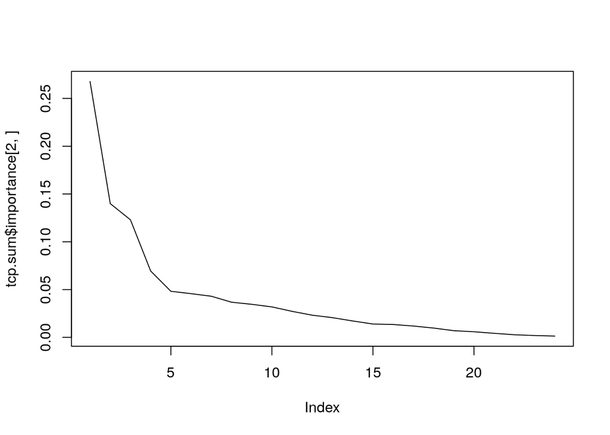

```
##   PC1   PC2   PC3   PC4   PC5   PC6   PC7   PC8   PC9  PC10  PC11  PC12
## FALSE FALSE FALSE FALSE FALSE FALSE FALSE FALSE FALSE FALSE FALSE FALSE
##  PC13  PC14  PC15  PC16  PC17  PC18  PC19  PC20  PC21  PC22  PC23  PC24
## FALSE FALSE FALSE  TRUE  TRUE  TRUE  TRUE  TRUE  TRUE  TRUE  TRUE  TRUE
##  PC25  PC26
##  TRUE  TRUE
```

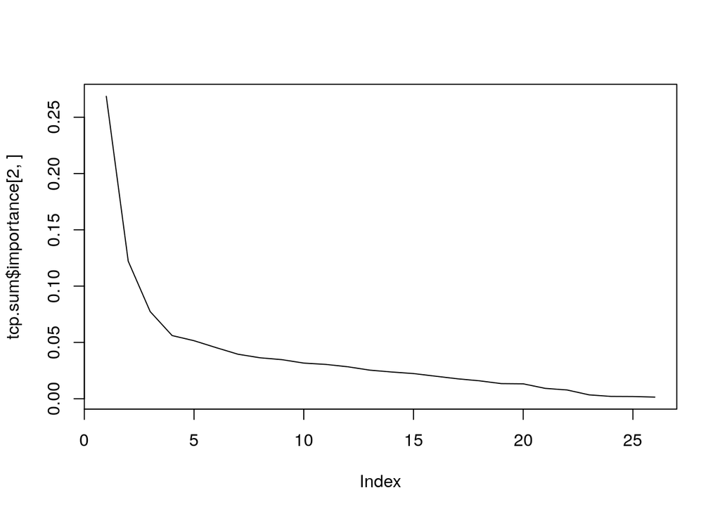

15. I know this is the old question 15, but I’m too lazy to change it. So please take it for what it is. Thanks!

```
##             Average         TotalPop              Men          Citizen
## 1 San Mateo Cluster 641264.956521739 7170.24590527519 68.0552016229281
## 2             Total 99068.5966438782 1109.76980611636  74.675072588377
##           Minority           Income        IncomeErr     IncomePerCap
## 1 42.5498918413214  87633.496888326 14367.7699253151 44857.9375166841
## 2 22.6687728423035 47221.7002616651 7081.75813224634 24000.7488885814
##    IncomePerCapErr          Poverty     ChildPoverty     Professional
## 1 6397.38670443513 11.4440220454287 13.9634812683195 47.3870111090017
## 2 3120.46035313414 17.5706570229159 23.8336932248276 30.8004060227024
##            Service           Office       Production            Drive
## 1 18.2156998501486 21.3076375931663 6.90909550156719 59.7471015795177
## 2  18.472858282297 22.1830928074174 15.8060173865796 79.1462674727629
##            Carpool           Transit      OtherTransp       WorkAtHome
## 1 8.17873868135592  19.4844907635362 2.30405272419776 5.26178086918955
## 2 10.3194871134777 0.989733401044941 1.62516443074591 4.60507443307083
##        MeanCommute         Employed      PrivateWork     SelfEmployed
## 1 30.4889608189669 52.4206889569052 77.4185683197954 6.22205743597723
## 2 23.3134361924172 43.0247144453537  74.183032238375  7.9164536646503
##          FamilyWork     Unemployment
## 1 0.104872437047605 7.31137206123604
## 2 0.287330219645564 8.15706443334943
```

```
##             Average         TotalPop              Men          Citizen
## 1 San Mateo Cluster 961279.707692308 10086.8833905852 68.1931490524078
## 2             Total 99068.5966438782 1109.76980611636  74.675072588377
##           Minority           Income        IncomeErr     IncomePerCap
## 1 40.9027987942498 81790.2991152374 12211.9919907539 37938.6154471851
## 2 22.6687728423035 47221.7002616651 7081.75813224634 24000.7488885814
##    IncomePerCapErr          Poverty     ChildPoverty     Professional
## 1 4831.71738142603 10.8639281781395 13.8257581406343 43.5640209728733
## 2 3120.46035313414 17.5706570229159 23.8336932248276 30.8004060227024
##            Service           Office       Production            Drive
## 1 16.8248012156676 23.8818515913458 8.73861393195904 72.3690770102443
## 2  18.472858282297 22.1830928074174 15.8060173865796 79.1462674727629
##            Carpool           Transit      OtherTransp       WorkAtHome
## 1 8.89514610154856  9.05983820311896 1.81640920118948 4.91323951087722
## 2 10.3194871134777 0.989733401044941 1.62516443074591 4.60507443307083
##        MeanCommute         Employed      PrivateWork     SelfEmployed
## 1 29.8422221266012 49.9941922216414 80.5560743401604 5.48462199847427
## 2 23.3134361924172 43.0247144453537  74.183032238375  7.9164536646503
##          FamilyWork     Unemployment
## 1 0.138199074257801 7.61715626803378
## 2 0.287330219645564 8.15706443334943
```

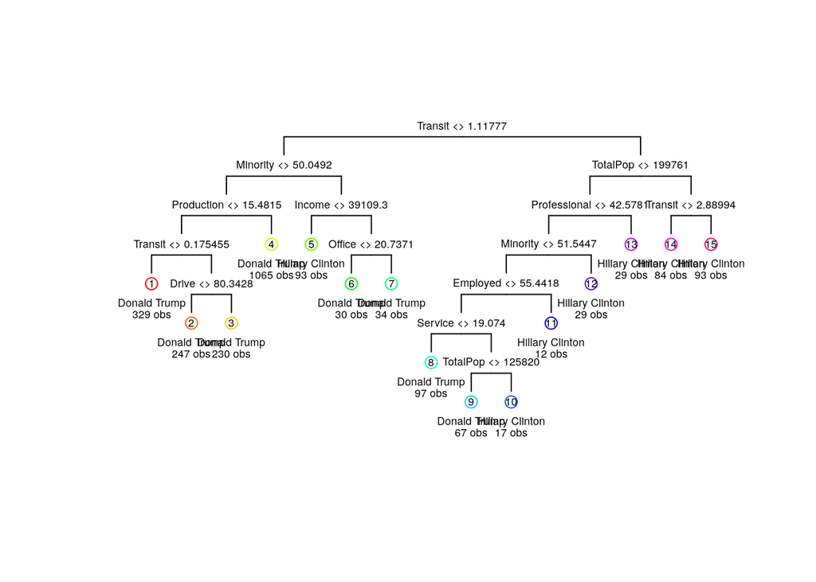

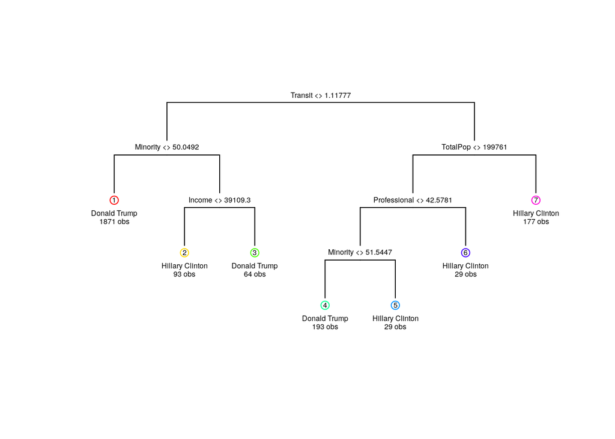

```
##          train.error test.error
## tree      0.06718241 0.07642276
## logistic          NA         NA
## lasso             NA         NA
## knn               NA         NA
## lda               NA         NA
```

17. See below for the significant variables. No, this isn’t entirely consistent with what we got out of the decision tree model. One of the variables that is rated differently is TotalPop, and I think it has to do with the fact that a decision tree might not be the best model in extrapolating insights for a variable concerning the entire populace and not just a segment of it.

```
##
## Call:
## glm(formula = candidate ~ ., family = "binomial", data = trn.cl)
##
## Deviance Residuals:
##     Min       1Q   Median       3Q      Max
## -3.9643  -0.2777  -0.1226  -0.0485   3.5079
##
## Coefficients:
##                   Estimate Std. Error z value Pr(>|z|)
## (Intercept)     -3.336e+01  6.001e+00  -5.558 2.72e-08 ***
## TotalPop         6.823e-07  2.014e-06   0.339 0.734788
## Men             -1.782e-05  1.859e-04  -0.096 0.923621
## Citizen          1.231e-01  2.851e-02   4.317 1.58e-05 ***
## Minority         1.255e-01  9.141e-03  13.727  < 2e-16 ***
## Income          -3.227e-05  2.513e-05  -1.284 0.199125
## IncomeErr       -2.917e-05  6.088e-05  -0.479 0.631836
## IncomePerCap     1.744e-04  6.012e-05   2.901 0.003725 **
## IncomePerCapErr -2.040e-04  1.324e-04  -1.541 0.123275
## Poverty          4.701e-02  4.039e-02   1.164 0.244515
## ChildPoverty    -1.269e-02  2.443e-02  -0.519 0.603480
## Professional     2.457e-01  3.705e-02   6.632 3.31e-11 ***
## Service          3.205e-01  4.660e-02   6.879 6.05e-12 ***
## Office           9.447e-02  4.424e-02   2.135 0.032742 *
## Production       1.557e-01  4.111e-02   3.787 0.000152 ***
## Drive           -1.817e-01  4.406e-02  -4.124 3.73e-05 ***
## Carpool         -1.447e-01  5.809e-02  -2.491 0.012738 *
## Transit          9.364e-02  8.980e-02   1.043 0.297012
## OtherTransp     -7.476e-02  9.039e-02  -0.827 0.408144
## WorkAtHome      -1.120e-01  7.159e-02  -1.564 0.117720
## MeanCommute      2.710e-02  2.390e-02   1.134 0.256728
## Employed         1.514e-01  3.140e-02   4.823 1.42e-06 ***
## PrivateWork      8.049e-02  2.126e-02   3.785 0.000154 ***
## SelfEmployed     1.470e-02  4.651e-02   0.316 0.752006
## FamilyWork      -9.991e-01  3.906e-01  -2.558 0.010524 *
## Unemployment     1.548e-01  3.761e-02   4.116 3.86e-05 ***
## ---
## Signif. codes:  0 '***' 0.001 '**' 0.01 '*' 0.05 '.' 0.1 ' ' 1
##
## (Dispersion parameter for binomial family taken to be 1)
##
##     Null deviance: 2078.43  on 2455  degrees of freedom
## Residual deviance:  877.39  on 2430  degrees of freedom
## AIC: 929.39
##
## Number of Fisher Scoring iterations: 7
```

```
##          train.error test.error
## tree      0.06718241 0.07642276
## logistic  0.11359935 0.09268293
## lasso             NA         NA
## knn               NA         NA
## lda               NA         NA
```

18. The optimal value of lambda is .001, and its non-zero coefficients are as listed below in the output.

```
## [1] 0.001
```

```
## 26 x 1 sparse Matrix of class "dgCMatrix"
##                             1
## (Intercept)     -3.434552e+01
## TotalPop         5.721826e-07
## Men              .
## Citizen          1.361793e-01
## Minority         1.151500e-01
## Income           .
## IncomeErr       -3.102336e-05
## IncomePerCap     9.128049e-05
## IncomePerCapErr -7.624143e-05
## Poverty          4.069682e-02
## ChildPoverty     .
## Professional     2.037145e-01
## Service          2.673949e-01
## Office           5.534122e-02
## Production       1.053640e-01
## Drive           -1.242681e-01
## Carpool         -8.982297e-02
## Transit          1.254037e-01
## OtherTransp      .
## WorkAtHome      -3.859195e-02
## MeanCommute      4.194026e-03
## Employed         1.454218e-01
## PrivateWork      7.438512e-02
## SelfEmployed     .
## FamilyWork      -7.950016e-01
## Unemployment     1.446124e-01
```

```
##          train.error test.error
## tree      0.06718241 0.07642276
## logistic  0.11359935 0.09268293
## lasso     0.06881107 0.07642276
## knn               NA         NA
## lda               NA         NA
```

```
##          train.error test.error
## tree      0.06718241 0.07642276
## logistic  0.11359935 0.09268293
## lasso     0.06881107 0.07642276
## knn       0.20276873 0.21091205
## lda       0.06636808 0.08130081
```